# TCC

Tiago de Almeida Silva

2023-01-06

Carregando os pacotes

```r
pacotes <- c("plotly", "tidyverse", "ggrepel", "knitr", "kableExtra","reshape2",
             "misc3d", "plot3D", "cluster","factoextra", "ade4","flexclust",
             "factoextra","ggpubr","openxlsx", "arrow", "tmap", "rgdal",
             "maptools", "leaflet", "Hmisc", "corrplot",
             "PerformanceAnalytics", "vtable", "fmsb", "scales", "showtext",
             "raster","tmap","rgdal","rayshader")

if(sum(as.numeric(!pacotes %in% installed.packages())) != 0){
  instalador <- pacotes[!pacotes %in% installed.packages()]
  for(i in 1:length(instalador)) {
    install.packages(instalador, dependencies = T)
    break()}
  sapply(pacotes, require, character = T)
} else {
  sapply(pacotes, require, character = T)
}
```

Carregando dataset

```r
df_tcc <- readxl::read_xlsx("df_tcc.xlsx", col_names = T)
```

Correlação da base de Dados

Matriz de Correlação de Pearson com nível de significância

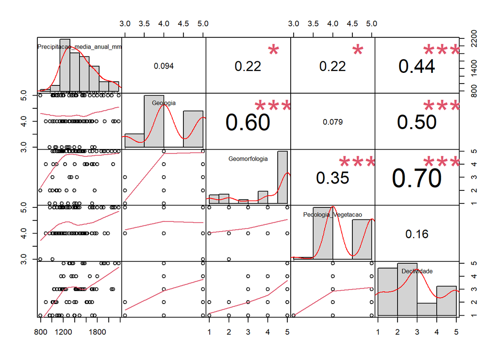

```r
correl <- rcorr(as.matrix(df_tcc[ ,c(4,6:9)]))

 chart.Correlation(df_tcc[ ,c(4,6:9)], histogram = T, pch = 19, method = "pearson")
```

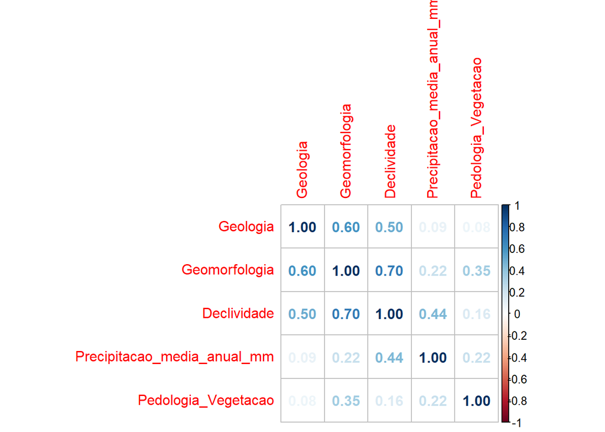

```r
 corrplot(correl$r, type = "full", order = "hclust", method = "number")
```

#Estatisticas Descritivas dos dados

```r
summary(df_tcc[ ,c(4,6:9)])
```

```
##  Precipitacao_media_anual_mm    Geologia     Geomorfologia
##  Min.   : 797                Min.   :3.000   Min.   :1.000
##  1st Qu.:1174                1st Qu.:4.000   1st Qu.:3.750
##  Median :1366                Median :4.000   Median :5.000
##  Mean   :1401                Mean   :4.228   Mean   :4.054
##  3rd Qu.:1584                3rd Qu.:5.000   3rd Qu.:5.000
##  Max.   :2174                Max.   :5.000   Max.   :5.000
##  Pedologia_Vegetacao  Declividade
##  Min.   :3.000       Min.   :1.000
##  1st Qu.:4.000       1st Qu.:2.000
##  Median :4.000       Median :3.000
##  Mean   :4.402       Mean   :2.989
##  3rd Qu.:5.000       3rd Qu.:4.000
##  Max.   :5.000       Max.   :5.000
```

```r
st(df_tcc[ ,c(4,6:9)], title = "Estatísticas Descritivas")
```

Estatísticas Descritivas

| Variable | N | Mean | Std. Dev. | Min | Pctl. 25 | Pctl. 75 | Max |
| --- | --- | --- | --- | --- | --- | --- | --- |
| Precipitacao_media_anual_mm | 92 | 1400.62 | 316.527 | 797 | 1173.6 | 1583.665 | 2174 |
| Geologia | 92 | 4.228 | 0.665 | 3 | 4 | 5 | 5 |
| Geomorfologia | 92 | 4.054 | 1.409 | 1 | 3.75 | 5 | 5 |
| Pedologia_Vegetacao | 92 | 4.402 | 0.536 | 3 | 4 | 5 | 5 |
| Declividade | 92 | 2.989 | 1.338 | 1 | 2 | 4 | 5 |

Padronização dos dados Dados (Z-score)

```r
df_padronizado <- as.data.frame(scale(df_tcc[,c(4, 6:9)]))
rownames(df_padronizado) <- df_tcc$nome
```

#Esquema de aglomeração não hierárquico K-MEANS (Machine Learning)

Elaboração da clusterização não hieráquica k-means

```r
set.seed(123)

cluster_kmeans <- kmeans(df_padronizado[ ,1:5],
                         centers = 5)
```

Método de Elbow para identificação do número ótimo de clusters

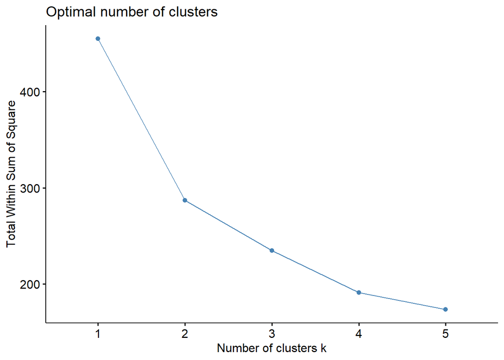

```r
fviz_nbclust(df_padronizado[ ,1:5], kmeans, method = "wss", k.max = 5)
```

Criando variável categórica para indicação do cluster no banco de dados

```r
df_padronizado$cluster_K <- factor(cluster_kmeans$cluster)
```

# Análise de variância de um fator (ANOVA)

ANOVA da variável ‘precipitação’

```r
summary(anova_matematica <- aov(formula = Precipitacao_media_anual_mm ~ cluster_K,data = df_padronizado))
```

```
##             Df Sum Sq Mean Sq F value   Pr(>F)
## cluster_K    4  43.71  10.928    20.1 9.43e-12 ***
## Residuals   87  47.29   0.544
## ---
## Signif. codes:  0 '***' 0.001 '**' 0.01 '*' 0.05 '.' 0.1 ' ' 1
```

ANOVA da variável ‘Geologia’

```r
summary(anova_matematica <- aov(formula = Geologia ~ cluster_K,data = df_padronizado))
```

```
##             Df Sum Sq Mean Sq F value   Pr(>F)
## cluster_K    4  53.59   13.40   31.16 4.27e-16 ***
## Residuals   87  37.41    0.43
## ---
## Signif. codes:  0 '***' 0.001 '**' 0.01 '*' 0.05 '.' 0.1 ' ' 1
```

ANOVA da variável ‘Geomorfologia’

```r
summary(anova_matematica <- aov(formula = Geomorfologia ~ cluster_K,data = df_padronizado))
```

```
##             Df Sum Sq Mean Sq F value Pr(>F)
## cluster_K    4  77.97   19.49   130.2 <2e-16 ***
## Residuals   87  13.03    0.15
## ---
## Signif. codes:  0 '***' 0.001 '**' 0.01 '*' 0.05 '.' 0.1 ' ' 1
```

ANOVA da variável ‘Pedologia_Vegetacao’

```r
summary(anova_matematica <- aov(formula = Pedologia_Vegetacao ~ cluster_K,data = df_padronizado))
```

```
##             Df Sum Sq Mean Sq F value   Pr(>F)
## cluster_K    4  39.79   9.946    16.9 2.77e-10 ***
## Residuals   87  51.21   0.589
## ---
## Signif. codes:  0 '***' 0.001 '**' 0.01 '*' 0.05 '.' 0.1 ' ' 1
```

ANOVA da variável ‘Declividade’

```r
summary(anova_matematica <- aov(formula = Declividade ~ cluster_K,data = df_padronizado))
```

```
##             Df Sum Sq Mean Sq F value Pr(>F)
## cluster_K    4  65.91  16.477   57.12 <2e-16 ***
## Residuals   87  25.09   0.288
## ---
## Signif. codes:  0 '***' 0.001 '**' 0.01 '*' 0.05 '.' 0.1 ' ' 1
```

## Cluster com pesos

```r
df_padronizado$prec_p <- df_padronizado$Precipitacao_media_anual_mm * 0.2

df_padronizado$geo_p <- df_padronizado$Geologia * 0.15

df_padronizado$geomor_p <- df_padronizado$Geomorfologia * 0.2

df_padronizado$ped_p <- df_padronizado$Pedologia_Vegetacao * 0.1

df_padronizado$dec_p <- df_padronizado$Declividade * 0.35
```

#Esquema de aglomeração não hierárquico K-MEANS

Elaboração da clusterização não hieráquica k-means

```r
set.seed(123)

cluster_kmeans_p <- kmeans(df_padronizado[ ,7:11],
                         centers = 5)
```

Estatística sobre o cluster

```r
print(cluster_kmeans_p)
```

```
## K-means clustering with 5 clusters of sizes 12, 21, 18, 19, 22
##
## Cluster means:
##        prec_p       geo_p    geomor_p        ped_p       dec_p
## 1 -0.08216134  0.15534891  0.11055211  0.049368679  0.13360400
## 2  0.16086091  0.08818679  0.12744712 -0.003961088  0.50098115
## 3  0.15568611 -0.00136271  0.06324609  0.018259648 -0.04074448
## 4 -0.15915970 -0.01587915  0.10432763  0.013347696 -0.09350784
## 5 -0.09865721 -0.15408531 -0.32380316 -0.049614600 -0.43699102
##
## Clustering vector:
##                Angra dos Reis                       Aperibé
##                             2                             4
##                      Araruama                         Areal
##                             4                             2
##            Armação dos Búzios               Arraial do Cabo
##                             5                             5
##                Barra do Piraí                   Barra Mansa
##                             4                             4
##                  Belford Roxo                    Bom Jardim
##                             5                             2
##       Bom Jesus do Itabapoana                     Cabo Frio
##                             3                             5
##          Cachoeiras de Macacu                       Cambuci
##                             1                             4
##                     Carapebus     Comendador Levy Gasparian
##                             5                             3
##         Campos dos Goytacazes                     Cantagalo
##                             5                             2
##               Cardoso Moreira                         Carmo
##                             4                             1
##             Casimiro de Abreu           Conceição de Macabu
##                             3                             3
##                      Cordeiro                   Duas Barras
##                             2                             2
##               Duque de Caxias   Engenheiro Paulo de Frontin
##                             5                             2
##                    Guapimirim                 Iguaba Grande
##                             3                             4
##                      Itaboraí                       Itaguaí
```

[output cut: 57 more lines]

```
##             Trajano de Moraes                     Três Rios
##                             2                             1
##                       Valença                     Varre-Sai
##                             3                             2
##                     Vassouras                 Volta Redonda
##                             1                             3
##
## Within cluster sum of squares by cluster:
## [1] 0.5133343 1.4384234 0.8561053 0.8863680 1.9062413
##  (between_SS / total_SS =  73.8 %)
##
## Available components:
##
## [1] "cluster"      "centers"      "totss"        "withinss"     "tot.withinss"
## [6] "betweenss"    "size"         "iter"         "ifault"
```

Método de Elbow para identificação do número ótimo de clusters

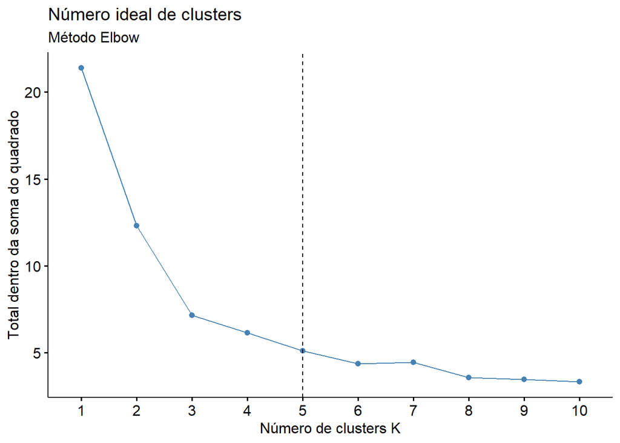

```r
fviz_nbclust(df_padronizado[ ,7:11], kmeans, method = "wss", k.max = 10) +
  geom_vline(xintercept = 5, linetype = 2)+
  labs(title = "Número ideal de clusters",
       subtitle = "Método Elbow",
       x = "Número de clusters K",
       y = "Total dentro da soma do quadrado")
```

Criando variável categórica para indicação do cluster no banco de dados

```r
df_padronizado$cluster_K_p <- factor(cluster_kmeans_p$cluster)
```

# Análise de variância de um fator (ANOVA)

ANOVA da variável ‘precipitação’

```r
summary(anova_prec <- aov(formula = Precipitacao_media_anual_mm ~ cluster_K_p,data = df_padronizado))
```

```
##             Df Sum Sq Mean Sq F value   Pr(>F)
## cluster_K_p  4   43.9  10.976   20.27 7.92e-12 ***
## Residuals   87   47.1   0.541
## ---
## Signif. codes:  0 '***' 0.001 '**' 0.01 '*' 0.05 '.' 0.1 ' ' 1
```

ANOVA da variável ‘Geologia’

```r
summary(anova_geom <- aov(formula = Geologia ~ cluster_K_p,data = df_padronizado))
```

```
##             Df Sum Sq Mean Sq F value   Pr(>F)
## cluster_K_p  4  43.56  10.890   19.97 1.08e-11 ***
## Residuals   87  47.44   0.545
## ---
## Signif. codes:  0 '***' 0.001 '**' 0.01 '*' 0.05 '.' 0.1 ' ' 1
```

ANOVA da variável ‘Geomorfologia’

```r
summary(anova_geomor <- aov(formula = Geomorfologia ~ cluster_K_p,data = df_padronizado))
```

```
##             Df Sum Sq Mean Sq F value Pr(>F)
## cluster_K_p  4  76.83  19.208   117.9 <2e-16 ***
## Residuals   87  14.17   0.163
## ---
## Signif. codes:  0 '***' 0.001 '**' 0.01 '*' 0.05 '.' 0.1 ' ' 1
```

ANOVA da variável ‘Pedologia_Vegetacao’

```r
summary(anova_ped <- aov(formula = Pedologia_Vegetacao ~ cluster_K_p,data = df_padronizado))
```

```
##             Df Sum Sq Mean Sq F value Pr(>F)
## cluster_K_p  4   9.31  2.3280   2.479 0.0498 *
## Residuals   87  81.69  0.9389
## ---
## Signif. codes:  0 '***' 0.001 '**' 0.01 '*' 0.05 '.' 0.1 ' ' 1
```

ANOVA da variável ‘Declividade’

```r
summary(anova_decl <- aov(formula = Declividade ~ cluster_K_p,data = df_padronizado))
```

```
##             Df Sum Sq Mean Sq F value Pr(>F)
## cluster_K_p  4  80.67  20.167   169.8 <2e-16 ***
## Residuals   87  10.33   0.119
## ---
## Signif. codes:  0 '***' 0.001 '**' 0.01 '*' 0.05 '.' 0.1 ' ' 1
```

Scatter plot

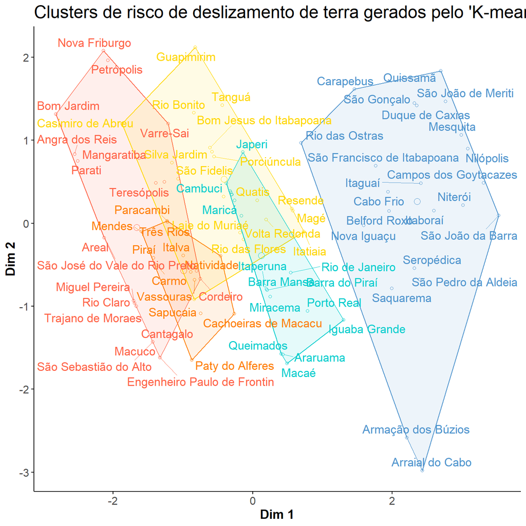

```r
fviz_cluster(cluster_kmeans_p, data = df_padronizado[ ,7:11],
             palette = c("darkorange1", "tomato", "gold1", "cyan3", "steelblue3"),
             geom = c("point", "text"),
             repel = T,
             ellipse.type = "convex",
             ggtheme = theme_classic(),
             main = "Clusters de risco de deslizamento de terra gerados pelo 'K-means'",
             labelsize = 14,
             xlab = "Dim 1",
             ylab = "Dim 2",
             shape = 1,
             ellipse.alpha = 0.1,
             legend = "none"
             ) + theme(axis.text=element_text(size=12),
          axis.title=element_text(size=14,face="bold"),
          title = element_text(size = 16))
```

Classificando as cidades com o grau de risco no dataset

```r
#Escala númerica

df_padronizado$grau_risco_deslizamento[df_padronizado$cluster_K_p == 5] <- 1
df_padronizado$grau_risco_deslizamento[df_padronizado$cluster_K_p == 4] <- 2
df_padronizado$grau_risco_deslizamento[df_padronizado$cluster_K_p == 3] <- 3
df_padronizado$grau_risco_deslizamento[df_padronizado$cluster_K_p == 1] <- 4
df_padronizado$grau_risco_deslizamento[df_padronizado$cluster_K_p == 2] <- 5

#Escala descritiva

df_padronizado$risco[df_padronizado$grau_risco_deslizamento == 1] <- "Muito Baixo"
df_padronizado$risco[df_padronizado$grau_risco_deslizamento == 2] <- "Baixo"
df_padronizado$risco[df_padronizado$grau_risco_deslizamento == 3] <- "Moderado"
df_padronizado$risco[df_padronizado$grau_risco_deslizamento == 4] <- "Alto"
df_padronizado$risco[df_padronizado$grau_risco_deslizamento == 5] <- "Muito Alto"
```

# Graficos dos clusteres

Com peso

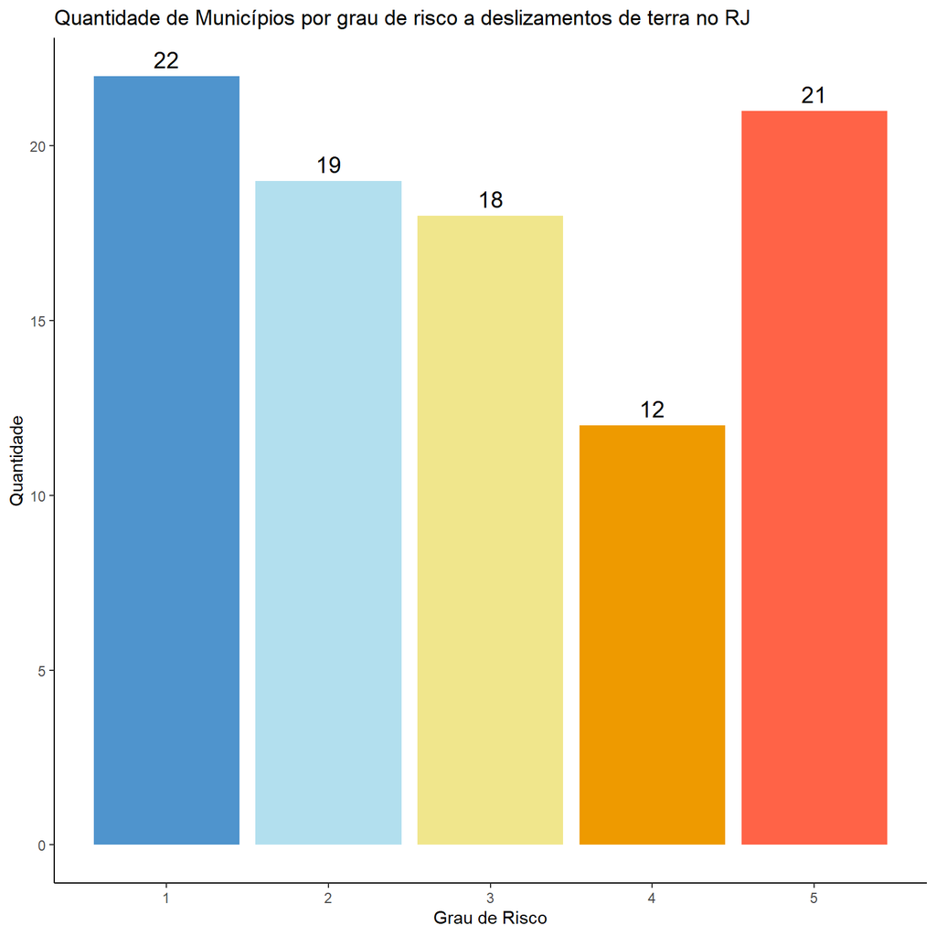

```r
ggplot(df_padronizado, aes(x = grau_risco_deslizamento)) +
  geom_bar(fill = c("steelblue3", "lightblue2", "khaki", "orange2", "tomato")) +
  labs(title = "Quantidade de Municípios por grau de risco a deslizamentos de terra no RJ",
       x = "Grau de Risco",
       y = "Quantidade") +
  geom_text(stat = "count", aes(label = ..count..), vjust = -0.5, size = 5) +
  theme_classic()
```

# Mapa

lendo o shapefile

```r
shp_rio <- readOGR(dsn = "RJ_shp", layer = "Base2018abril2019_equiv_albers",
                       encoding = "UTF-8", use_iconv = TRUE)
```

Juntando os datasets

```r
df_padronizado$mun <- rownames(df_padronizado)

shp_rio@data <- left_join(x = shp_rio@data,
                          y = df_padronizado,
                          by = c("MUNICN" = "mun"))
```

Plotando o mapa

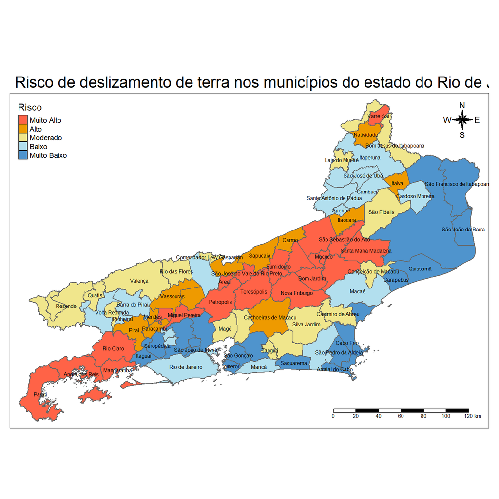

```r
tm_shape(shp = shp_rio) +
  tm_polygons("risco",
              palette = c("orange2", "lightblue2", "khaki", "tomato", "steelblue3"),
              legend.show = F) +
  tm_layout(main.title = "Risco de deslizamento de terra nos municípios do estado do Rio de Janeiro",
            title.size = 1.2) +
  tm_text("MUNICN", size = 0.5,
         remove.overlap = TRUE,
          col = "black") +
  tm_compass(type = "8star",
             show.labels = 2,
             size = 2,
             position = c("right", "top")) +
  tm_add_legend("fill",
    labels = c("Muito Alto",'Alto','Moderado','Baixo', "Muito Baixo"),
    col = c("tomato", "orange2", "khaki", "lightblue2", "steelblue3"),
    title="Risco") +
  tm_scale_bar()
```

```r
#labels = c("Muito Alto", "Alto", "Moderado", "Baixo", "Muito Baixo")
```

Mapa com relevo sombrado

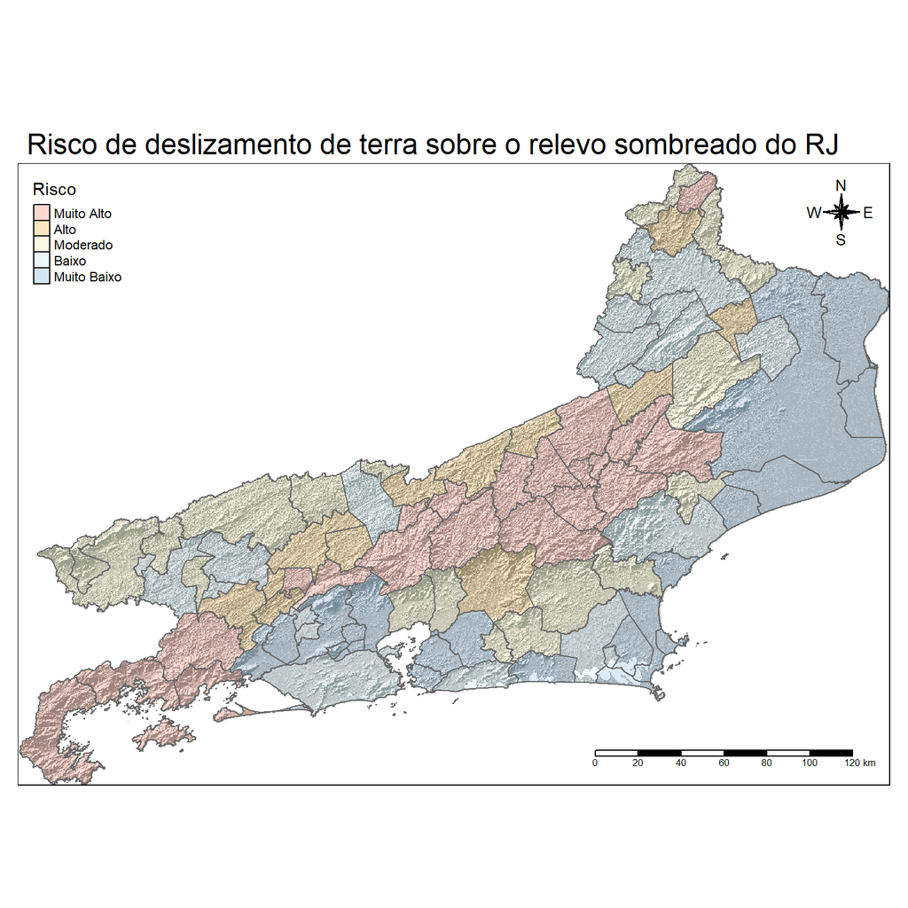

```r
relevo_rj <- raster("RelevoSombreado_SRTM/RelSomb_315_45.tif")

tm_shape(shp = relevo_rj) +
  tm_raster(style = "quantile", n = 5,
            palette = c("azure4","gray", "snow"),
                                legend.show = F) +
  tm_shape(shp = shp_rio) +
  tm_polygons("risco",
              alpha = 0.2,
              #title = "Risco de deslizamento de terra",
              #style = "pretty",
              palette = c("orange2", "lightblue2", "khaki", "tomato", "steelblue3"),
              legend.show = F) +
  tm_borders() +
  tm_layout(main.title = "Risco de deslizamento de terra sobre o relevo sombreado do RJ",
            title.size = 0.5) +
  tm_compass(type = "8star",
             show.labels = 2,
             size = 2,
             position = c("right", "top")) +
  tm_add_legend("fill",
    labels = c("Muito Alto",'Alto','Moderado','Baixo', "Muito Baixo"),
    col = alpha(c("tomato", "orange2", "khaki", "lightblue2", "steelblue3"), 0.25),
    title="Risco") +
  tm_scale_bar()
```

Quantidade de municípios em cada grau de risco por região do estado

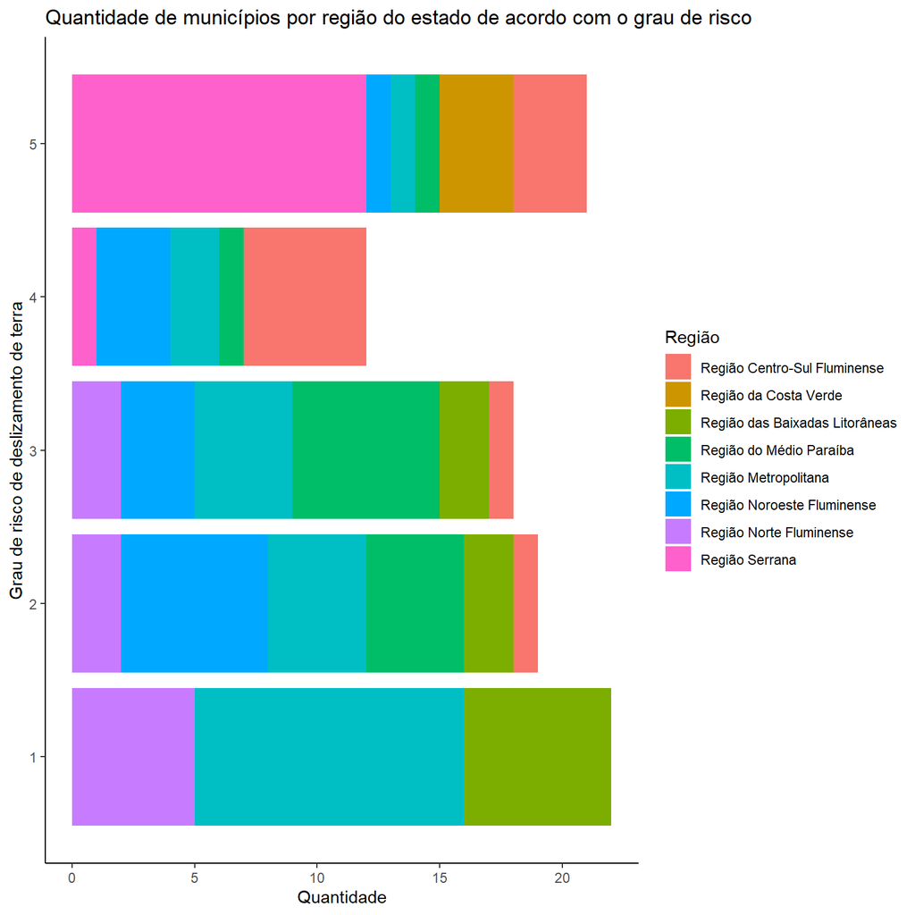

```r
# arrumando o nome das regiões

p <- ggplot(shp_rio@data, aes(y = grau_risco_deslizamento, fill = REGGOV)) +
  geom_bar() +
  labs(title = "Quantidade de municípios por região do estado de acordo com o grau de risco",
       y = "Grau de risco de deslizamento de terra",
       x = "Quantidade") +
  theme_classic()

p + guides(fill=guide_legend(title="Região"))
```

Gráfico de radar com regiões do estado

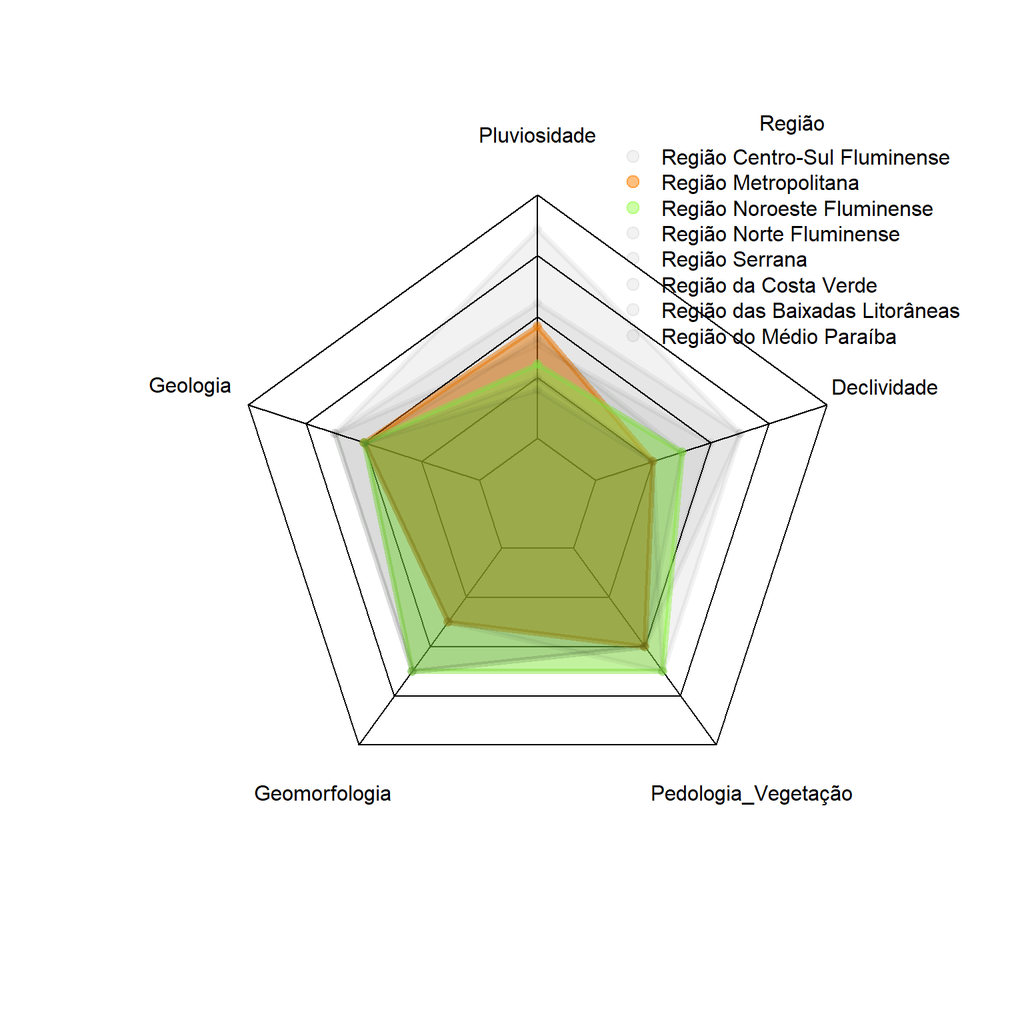

```r
set.seed(99)


#criando o dataset para o grafico

df_reg <- left_join(x = df_tcc,
                    y = shp_rio@data,
                    by =c("nome" = "MUNICN"))

df_reg <- df_reg %>%
  group_by(REGGOV) %>%
  summarise(Pluviosidade = round(mean(Precipitacao_media_anual_mm.x)),
            Geologia = round(mean(Geologia.x)),
            Geomorfologia = round(mean(Geomorfologia.x)),
            Pedologia_Vegetação = round(mean(Pedologia_Vegetacao.x)),
            Declividade = round(mean(Declividade.x)))

df_reg[9, 1] <- "Max."
df_reg[9, 2] <- 2000
df_reg[10, 1] <- "Min."
df_reg[10, 2] <- 1000

df_reg[9, 3:6] <- 8
df_reg[10, 3:6] <- 0

df_reg2 <-  df_reg[c(9,10,1:8), ]

rownames(df_reg2) <- df_reg2$REGGOV

areas <- c(rgb(0, 0.02, 0, 0.05),
           rgb(1, 0.5 , 0, 0.5),
           rgb(0.6, 1, 0.3, 0.5),
           rgb(0, 0.02, 0, 0.05),
           rgb(0, 0.02, 0, 0.05),
           rgb(0, 0.02, 0, 0.05),
           rgb(0, 0.02, 0, 0.05),
           rgb(0, 0.02, 0, 0.05))


radarchart(df_reg2[ ,2:6],
           cglty = 1,       # Tipo de línea del grid
           cglcol = "black", # Color del grid
           pcol = areas,      # Color para cada línea
           plwd = 4,        # Ancho para cada línea
           plty = 1,
           pfcol = areas,
           #title = "Região com maior e menor risco de deslizamento de terra explicitada por cada variável"
           )


legend("topright",
       legend = df_reg2$REGGOV[3:10],
       bty = "n", pch = 20,
       text.col = "black", pt.cex = 2, col = areas, title = "Região")
```

Dataset 2

```r
df2 <- left_join(df_padronizado,
                 df_tcc,
                 by =c("mun"="nome"))
```

```r
group_by(df2, grau_risco_deslizamento) %>%
  summarise(
    mean = mean(Precipitacao_media_anual_mm.y, na.rm = TRUE),
    sd = sd(Precipitacao_media_anual_mm.y, na.rm = TRUE),
    min = min(Precipitacao_media_anual_mm.y, na.rm = TRUE),
    max = max(Precipitacao_media_anual_mm.y, na.rm = TRUE))
```

```
## # A tibble: 5 x 5
##   grau_risco_deslizamento  mean    sd   min   max
##                     <dbl> <dbl> <dbl> <dbl> <dbl>
## 1                       1 1244.  265.  797  1751
## 2                       2 1149.  112.  893. 1427.
## 3                       3 1647.  188. 1426  2081
## 4                       4 1271.  147. 1033  1436.
## 5                       5 1655.  330. 1202. 2174
```

```r
group_by(df2, grau_risco_deslizamento) %>%
  summarise(
    mean = mean(Geologia.y, na.rm = TRUE),
    sd = sd(Geologia.y, na.rm = TRUE),
    min = min(Geologia.y, na.rm = TRUE),
    max = max(Geologia.y, na.rm = TRUE))
```

```
## # A tibble: 5 x 5
##   grau_risco_deslizamento  mean    sd   min   max
##                     <dbl> <dbl> <dbl> <dbl> <dbl>
## 1                       1  3.55 0.671     3     5
## 2                       2  4.16 0.375     4     5
## 3                       3  4.22 0.428     4     5
## 4                       4  4.92 0.289     4     5
## 5                       5  4.62 0.498     4     5
```

```r
group_by(df2, grau_risco_deslizamento) %>%
  summarise(
    mean = mean(Geomorfologia.y, na.rm = TRUE),
    sd = sd(Geomorfologia.y, na.rm = TRUE),
    min = min(Geomorfologia.y, na.rm = TRUE),
    max = max(Geomorfologia.y, na.rm = TRUE))
```

```
## # A tibble: 5 x 5
##   grau_risco_deslizamento  mean    sd   min   max
##                     <dbl> <dbl> <dbl> <dbl> <dbl>
## 1                       1  1.77 0.813     1     4
## 2                       2  4.79 0.419     4     5
## 3                       3  4.5  0.618     3     5
## 4                       4  4.83 0.577     3     5
## 5                       5  4.95 0.218     4     5
```

```r
group_by(df2, grau_risco_deslizamento) %>%
  summarise(
    mean = mean(Pedologia_Vegetacao.y, na.rm = TRUE),
    sd = sd(Pedologia_Vegetacao.y, na.rm = TRUE),
    min = min(Pedologia_Vegetacao.y, na.rm = TRUE),
    max = max(Pedologia_Vegetacao.y, na.rm = TRUE))
```

```
## # A tibble: 5 x 5
##   grau_risco_deslizamento  mean    sd   min   max
##                     <dbl> <dbl> <dbl> <dbl> <dbl>
## 1                       1  4.14 0.560     3     5
## 2                       2  4.47 0.513     4     5
## 3                       3  4.5  0.514     4     5
## 4                       4  4.67 0.492     4     5
## 5                       5  4.38 0.498     4     5
```

```r
group_by(df2, grau_risco_deslizamento) %>%
  summarise(
    mean = mean(Declividade.y, na.rm = TRUE),
    sd = sd(Declividade.y, na.rm = TRUE),
    min = min(Declividade.y, na.rm = TRUE),
    max = max(Declividade.y, na.rm = TRUE))
```

```
## # A tibble: 5 x 5
##   grau_risco_deslizamento  mean    sd   min   max
##                     <dbl> <dbl> <dbl> <dbl> <dbl>
## 1                       1  1.32 0.477     1     2
## 2                       2  2.63 0.597     1     3
## 3                       3  2.83 0.383     2     3
## 4                       4  3.5  0.522     3     4
## 5                       5  4.90 0.301     4     5
```

Radar 2

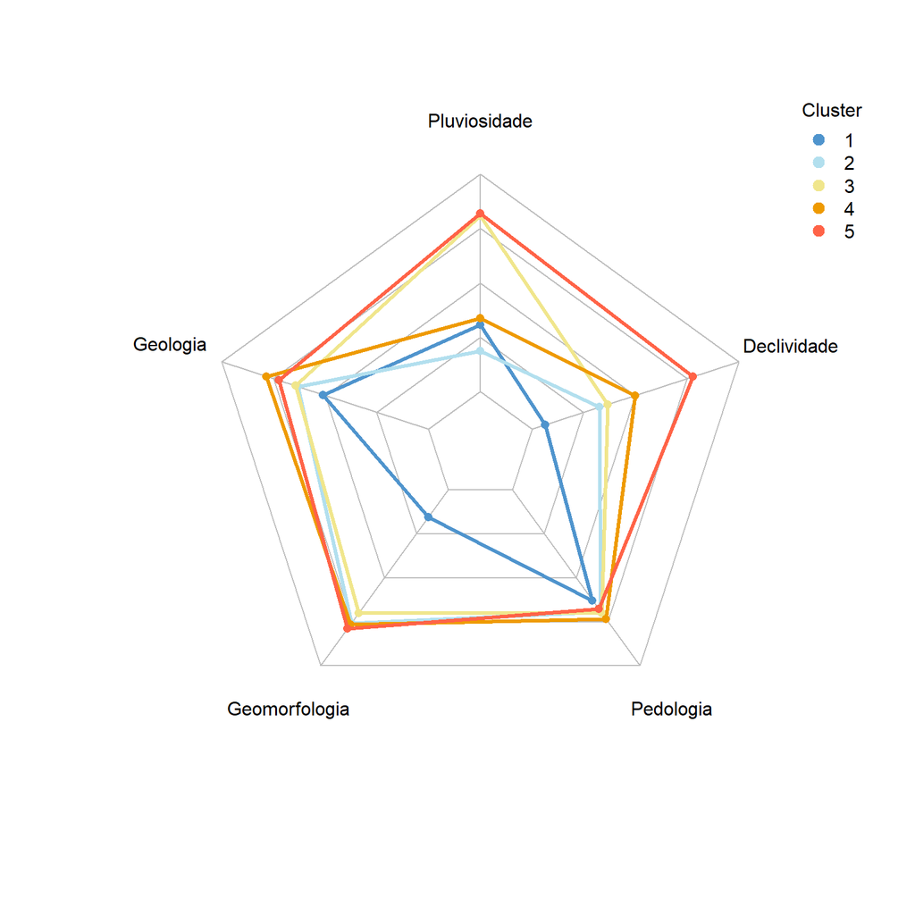

```r
radar2 <- readxl::read_xlsx("radar2.xlsx", col_names = T)

rownames(radar2) <- radar2$Cluster

class(radar2$Declividade) <- "numeric"

areas2 <- c("steelblue3", "lightblue2", "khaki", "orange2", "tomato")


radarchart(radar2[ ,2:6],
           cglty = 1,       # Tipo de línea del grid
           cglcol = "gray", # Color del grid
           pcol = areas2,      # Color para cada línea
           plwd = 3,        # Ancho para cada línea
           plty = 1)


legend("topright",
       legend = radar2$Cluster[3:7],
       bty = "n", pch = 20,
       text.col = "black", pt.cex = 2, col = areas2,
       title = "Cluster")
```